# Make Fake Album Cover Game

### About the Authors:

[James Reeve](https://www.linkedin.com/in/reevejamesd/) James Reeves is a Software Engineering intern at IBM.

[Joseph Santarcangelo](https://www.linkedin.com/in/joseph-s-50398b136/) has a PhD in Electrical Engineering, his research focused on using machine learning, signal processing, and computer vision to determine how videos impact human cognition. Joseph has been working for IBM since he completed his PhD.

```python
import requests
```

```python
wikipedia_link='https://en.wikipedia.org/wiki/Pages_(band)'
```

```python
raw_random_wikipedia_page=requests.get(wikipedia_link)
```

```python
page=raw_random_wikipedia_page.text
print(page)
```

[output not shown]

[output cut: 343 more lines]

[output not shown]

```python
title=page.find('<title>')
#print(title)
title2=page.find('</title>')
#print(title2)
band=page[101:113]
print(band)
```

```
Pages (band)
```

```python
wikipedia_link='https://en.wikipedia.org/wiki/Love_Yourself'
```

```python
raw_random_wikipedia_page=requests.get(wikipedia_link)
```

```python
page=raw_random_wikipedia_page.text
print(page)
```

[output not shown]

[output cut: 1287 more lines]

[output not shown]

```python
title=page.find('<title>')
#print(title)
title2=page.find('</title>')
#print(title2)
album=page[101:115]
print(album)
```

```
Love Yourself
```

```python
img=display_cover(top=band,bottom=album)
```

```python
img.save('sample-out.png')
```

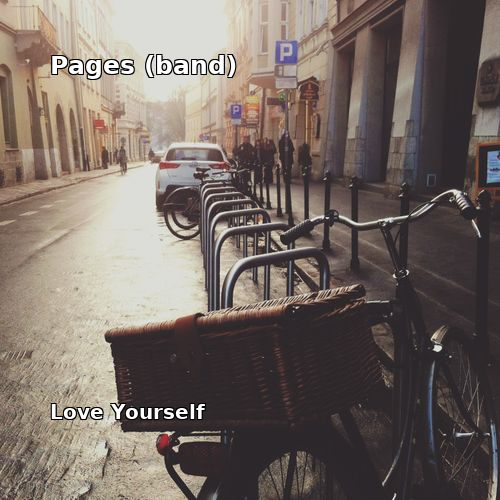

```python
IPythonImage(filename='sample-out.png')
```

Copyright © 2018 cognitiveclass.ai. This notebook and its source code are released under the terms of the [MIT License](https://bigdatauniversity.com/mit-license/).